# Homework 10

Yuanji Sun

December 6, 2017

# Report process

I ran into and solved the following problems when doing this homework.

1. API key must be put in double quotation mark. Otherwise, the function will not work.
2. The raw weather data of different cities has different lengths, and even for the same city, the data length will change when the data is updated every a few hours. Thus, I selected the most important and common vaiables and created a dataframe.
3. For Part 3, I noticed that the missing value was in `nd` on the website. In order to generate an empty figure if all values are missing, I should use `na.strings = "nd"` and then convert it to numeric form. This is because I cannot use `NA_integer_` or other similar code in `read.table()`.
4. There is a bug of `ggplot()`. In the for loop, I used `ggplot(data=data, mapping=colnames(data)[j], y="depth"))`. Yes, it is right logically but when `j` changes, the previous figure will also be changed. This is because even though the figure is generated and saved in `plot_list`, the figure is still linked with `j` and will change. Thus, in my first trial, all figures were the same except the axis names.

Overall, this homework is finished smoothly. Many problems occurred in Part 3 but they were solved finally. This work will benefit me a lot in doing my research based on big data set in Oceanography. In the future, I only need to change the top-level URL of the database and then all sub-datapage can be analyzed without downloading any files.

**Please be patient when running codes in Part 3. Large dataset will be analyzed and it will take sometime.**

**Useful resource**

1. Google
2. Lecture notes
3. R for Data Science

# Load libraries

```r
library(tidyverse)
library(httr)
library(magrittr)
library(purrr)
library(glue)
library(stringr)
library(rvest)
```

```r
library(xml2)
library(ggplot2)
library(cowplot)
library(knitr)
library(leaflet)
```

# Part 1: Work with OpenWeatherMap

Step 1: Write a function to get the weather data, and select important information for output.

**Remember to put your API Key in double quotation marks.**

```r
get_weather <- function(city_name, country_code, API_key) {
    query_string <- glue("api.openweathermap.org/data/2.5/weather?q={city_name},{country_code}&APPID={API_key}")
    weather_result <- GET(query_string)
    weather_content <- data.frame(content(weather_result))
    weather_output <- weather_content %>%
            select(name, sys.country, coord.lon, coord.lat, weather.description, main.temp)
    return(weather_output)
}
```

Step 2: Get weather information of major cities in China. To get your own API key, please visit [Open Weather Map](https://openweathermap.org/api). A free API is enough for this homework.

```r
result_Beijing <- get_weather("Beijing","CN","7ce93051a99b9283279834f10c83f037")
result_Hangzhou <- get_weather("Hangzhou","CN","7ce93051a99b9283279834f10c83f037")
result_Shanghai <- get_weather("Shanghai","CN","7ce93051a99b9283279834f10c83f037")
result_Xiamen <- get_weather("Xiamen","CN","7ce93051a99b9283279834f10c83f037")
result_Chengdu <- get_weather("Chengdu","CN","7ce93051a99b9283279834f10c83f037")
result_Harbin <- get_weather("Harbin","CN","7ce93051a99b9283279834f10c83f037")
result_Tianjin <- get_weather("Tianjin","CN","7ce93051a99b9283279834f10c83f037")
result_Shijiazhuang <- get_weather("Shijiazhuang","CN","7ce93051a99b9283279834f10c83f037")
result_Xian <- get_weather("Xian","CN","7ce93051a99b9283279834f10c83f037")
result_Jinan <- get_weather("Jinan","CN","7ce93051a99b9283279834f10c83f037")
result_Zhenzhou <- get_weather("Zhenzhou","CN","7ce93051a99b9283279834f10c83f037")
result_Wuhan <- get_weather("Wuhan","CN","7ce93051a99b9283279834f10c83f037")
result_Guiyang <- get_weather("Guiyang","CN","7ce93051a99b9283279834f10c83f037")
result_Changsha <- get_weather("Changsha","CN","7ce93051a99b9283279834f10c83f037")
result_Lanzhou <- get_weather("Lanzhou","CN","7ce93051a99b9283279834f10c83f037")
result_Kunming <- get_weather("Kunming","CN","7ce93051a99b9283279834f10c83f037")
result_Nanning <- get_weather("Nanning","CN","7ce93051a99b9283279834f10c83f037")
result_Guangzhou <- get_weather("Guangzhou","CN","7ce93051a99b9283279834f10c83f037")
result_Shenyang <- get_weather("Shenyang","CN","7ce93051a99b9283279834f10c83f037")
result_Changchun <- get_weather("Changchun","CN","7ce93051a99b9283279834f10c83f037")
result_Nanchang <- get_weather("Nanchang","CN","7ce93051a99b9283279834f10c83f037")
result_df <- rbind(result_Beijing, result_Hangzhou, result_Shanghai, result_Xiamen, result_Chengdu,
           result_Harbin, result_Tianjin, result_Shijiazhuang, result_Xian, result_Jinan,
           result_Zhenzhou, result_Guiyang, result_Wuhan, result_Changsha, result_Lanzhou,
           result_Kunming, result_Nanning, result_Guangzhou, result_Shenyang,
           result_Changchun, result_Nanchang)
colnames(result_df) <- c("City", "Country", "longitude", "latitude", "Weather", "Temperature")
result_df
```

```
##            City Country longitude latitude         Weather Temperature
## 1       Beijing      CN    116.40    39.91       clear sky     282.150
## 2      Hangzhou      CN    120.16    30.29       clear sky     281.150
## 3      Shanghai      CN    121.46    31.22       clear sky     281.150
## 4        Xiamen      CN    118.08    24.48       clear sky     290.150
## 5       Chengdu      CN    104.07    30.67       clear sky     289.150
## 6        Harbin      CN    126.65    45.75      light snow     263.150
## 7       Tianjin      CN    117.18    39.14       clear sky     280.150
## 8  Shijiazhuang      CN    114.48    38.04       clear sky     284.150
## 9          Xian      CN    108.93    34.26       clear sky     280.150
## 10        Jinan      CN    117.00    36.67       clear sky     275.042
## 11     Zhenzhou      CN    119.18    32.27       clear sky     280.150
## 12      Guiyang      CN    106.72    26.58 overcast clouds     279.150
## 13        Wuhan      CN    114.27    30.58       clear sky     283.150
## 14     Changsha      CN    112.97    28.20       clear sky     287.150
## 15      Lanzhou      CN    103.79    36.06       clear sky     272.150
## 16      Kunming      CN    102.72    25.04            mist     278.150
## 17      Nanning      CN    108.32    22.82       clear sky     291.150
## 18    Guangzhou      CN    113.25    23.12       clear sky     293.150
## 19     Shenyang      CN    123.43    41.79       clear sky     273.150
## 20    Changchun      CN    125.32    43.88      light snow     264.150
## 21     Nanchang      CN    115.88    28.68       clear sky     280.092
```

Step 3: Make an interactive map using `leaflet()` and add weather information on the pop-up.

**To view this map, please see HTML version. Map is NOT supported in MD file.**

```r
result_df %>%
        leaflet() %>%
        addProviderTiles(providers$Esri.NatGeoWorldMap) %>%
        addMarkers(popup = ~ Weather)
```

```
## Assuming 'longitude' and 'latitude' are longitude and latitude, respectively
```

[interactive chart not shown]

Step 4: Modify the function with a for loop.

It is a waste of time to get data one by one. I would like to enter all cities once and call the function only once. **This work is only designed for Chinese cities with a weather map (single country), so the country code is only “CN”. If you want to use this for more than one countries, the function needs to be modified slightly.**

```r
get_weather_2 <- function(city_name, country_code, API_key) {
    all_result <- data.frame(matrix(ncol = 6, nrow = 0))
    col_name <- c("name", "sys.country", "coord.lon", "coord.lat", "weather.description", "main.temp")
    colnames(all_result) <- col_name
        for (i in 1:length(city_name)){
                query_string<-glue("api.openweathermap.org/data/2.5/weather?q={city_name[i]},{country_code}&APPID={API_key}")
                weather_result <- GET(query_string)
                weather_content <- data.frame(content(weather_result))
                weather_output <- weather_content %>%
                    select(name, sys.country, coord.lon, coord.lat, weather.description, main.temp)
                all_result <- rbind(all_result, weather_output)
        }
    return(all_result)
}
```

Let’s have a try, getting a full results and an interactive map.

```r
city <- c("Beijing","Hangzhou","Shanghai","Xiamen","Chengdu","Harbin","Tianjin","Shijiazhuang","Xian",
      "Jinan","Zhenzhou","Wuhan","Guiyang","Changsha","Lanzhou","Kunming","Nanning","Guangzhou",
      "Shenyang","Changchun","Nanchang")
weather_all_city <- get_weather_2(city,"CN","7ce93051a99b9283279834f10c83f037")
colnames(result_df) <- c("City", "Country", "longitude", "latitude", "Weather", "Temperature")
result_df %>%
        leaflet() %>%
        addProviderTiles(providers$Esri.NatGeoWorldMap) %>%
        addMarkers(popup = ~ Weather)
```

```
## Assuming 'longitude' and 'latitude' are longitude and latitude, respectively
```

[interactive chart not shown]

# Part 2: Analyze oceanographic data (JGOFS) from single webpage

Step 1: Get the URL of the data set and store the URL contents to a variable.

```r
url <- "http://usjgofs.whoi.edu/jg/serv/jgofs/arabian/ttn-039/bottle.flat1?event%20eq%20092111.0"
page_title <- read_html(url)
```

Step 2: Extract the data in the text form.

```r
txt_data <- xml_text(page_title)
```

Step 3: Convert the text data into a dataframe.

```r
data <- read.table(text=txt_data,skip=1,col.names=c('event','sta', "cast", "date", "time", "lat_begin",
    "lon_begin", "bot", "press","temp", "sal_bot","O2_ml_L", "O2_umol_kg", "O2_umol_L", "O2_4", "NO3",
    "PO4", "SiO4", "NO2", "NH4"))
data$depth <- -data$press
data
```

```
##    event sta cast     date time lat_begin lon_begin bot press   temp
## 1  92111   1    1 19940921   11     5.687    87.965  24   0.7 28.397
## 2  92111   1    1 19940921   11     5.687    87.965  23   0.7 28.399
## 3  92111   1    1 19940921   11     5.687    87.965  22  26.2 28.145
## 4  92111   1    1 19940921   11     5.687    87.965  21  51.3 28.052
## 5  92111   1    1 19940921   11     5.687    87.965  20  75.9 26.386
## 6  92111   1    1 19940921   11     5.687    87.965  19 101.2 21.500
## 7  92111   1    1 19940921   11     5.687    87.965  18 101.3 21.450
## 8  92111   1    1 19940921   11     5.687    87.965  17 101.2 21.337
## 9  92111   1    1 19940921   11     5.687    87.965  16 151.1 13.812
## 10 92111   1    1 19940921   11     5.687    87.965  15 201.5 13.141
## 11 92111   1    1 19940921   11     5.687    87.965  14 201.7 13.141
## 12 92111   1    1 19940921   11     5.687    87.965  13 202.0 13.135
## 13 92111   1    1 19940921   11     5.687    87.965  12 252.0 11.979
## 14 92111   1    1 19940921   11     5.687    87.965  11 302.4 11.201
```

[output cut: 60 more lines]

Step 4: Generate figures for selected variable vs `press`. In Oceanography, `press` can be taken as depth.

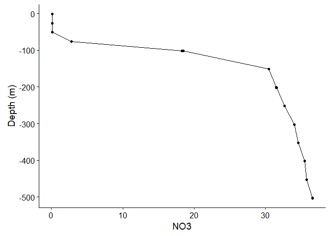

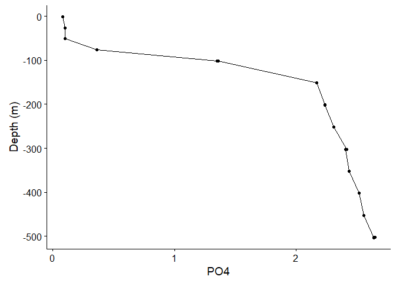

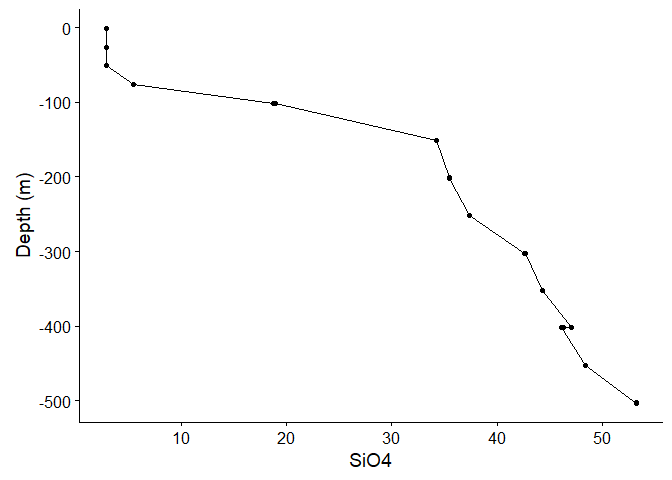

```r
plot_list = list()
for (i in 16:18) {
        variable <- colnames(data)[i]
        plot_list[[i-15]] <- ggplot(data=data, mapping=aes_string(x=variable, y="depth")) +
            geom_point() +
            geom_path() +
                labs(x = colnames(data)[i], y = "Depth (m)")
}
print(plot_list)
```

# Part 3: Analyze oceanographic data (JGOFS) automatically from multiple webpage

```r
main_URL <- "http://usjgofs.whoi.edu/jg/serv/jgofs/arabian/ttn-039/bottle.html0%7Bdir=usjgofs.whoi.edu/jg/dir/jgofs/arabian/ttn-039/,info=usjgofs.whoi.edu/jg/info/jgofs/arabian/ttn-039/bottle%7D"
```

Step 2: Extract event numbers in the webpage. All data in the dataframe are stored in character form.

```r
main_page_title <- read_html(main_URL)
raw_info <- main_page_title %>% xml_text()
info <- read.table(text=raw_info,skip=13,col.names=c("event", "sta", "cast", "date", "time", "lat_begin",
                                                        "lon_begin"), colClasses = "character")
event <- info$event
```

Step 3: Modify the event number by adding `20` before the number. This is because the link of the data ending with `20` + event numbers.

```r
for (i in 1:length(event)){
      event[i] <- paste("20", event[i], sep = "")
}
```

Step 4: Generating URLs for all data webpage. The URL has the commmon format, “http://usjgofs.whoi.edu/jg/serv/jgofs/arabian/ttn-039/bottle.flat1?event%20eq%” + event number. Let’s have a look at all websites and check some of them.

```r
sub_URL = ""
for (i in 1:length(event)){
      sub_URL[i] <- paste("http://usjgofs.whoi.edu/jg/serv/jgofs/arabian/ttn-039/bottle.flat1?event%20eq%",
        event[i], sep = "")
}
sub_URL
```

```
##  [1] "http://usjgofs.whoi.edu/jg/serv/jgofs/arabian/ttn-039/bottle.flat1?event%20eq%20092111.0"
##  [2] "http://usjgofs.whoi.edu/jg/serv/jgofs/arabian/ttn-039/bottle.flat1?event%20eq%20092601.7"
##  [3] "http://usjgofs.whoi.edu/jg/serv/jgofs/arabian/ttn-039/bottle.flat1?event%20eq%20092616.7"
##  [4] "http://usjgofs.whoi.edu/jg/serv/jgofs/arabian/ttn-039/bottle.flat1?event%20eq%20092620.2"
##  [5] "http://usjgofs.whoi.edu/jg/serv/jgofs/arabian/ttn-039/bottle.flat1?event%20eq%20092621.3"
##  [6] "http://usjgofs.whoi.edu/jg/serv/jgofs/arabian/ttn-039/bottle.flat1?event%20eq%20092702.1"
##  [7] "http://usjgofs.whoi.edu/jg/serv/jgofs/arabian/ttn-039/bottle.flat1?event%20eq%20092708.0"
##  [8] "http://usjgofs.whoi.edu/jg/serv/jgofs/arabian/ttn-039/bottle.flat1?event%20eq%20092714.1"
##  [9] "http://usjgofs.whoi.edu/jg/serv/jgofs/arabian/ttn-039/bottle.flat1?event%20eq%20092720.5"
## [10] "http://usjgofs.whoi.edu/jg/serv/jgofs/arabian/ttn-039/bottle.flat1?event%20eq%20092801.7"
## [11] "http://usjgofs.whoi.edu/jg/serv/jgofs/arabian/ttn-039/bottle.flat1?event%20eq%20092809.7"
## [12] "http://usjgofs.whoi.edu/jg/serv/jgofs/arabian/ttn-039/bottle.flat1?event%20eq%20092802.2"
## [13] "http://usjgofs.whoi.edu/jg/serv/jgofs/arabian/ttn-039/bottle.flat1?event%20eq%20092903.9"
## [14] "http://usjgofs.whoi.edu/jg/serv/jgofs/arabian/ttn-039/bottle.flat1?event%20eq%20092920.2"
## [15] "http://usjgofs.whoi.edu/jg/serv/jgofs/arabian/ttn-039/bottle.flat1?event%20eq%20093007.4"
```

[output cut: 22 more lines]

```r
sub_URL <- sub_URL[-2]
```

**If all data in the data set is “NA”, an empty plot will be returned. Also, if there are too many `NA` values (only a few valid data points), there will be no line in the figure.**

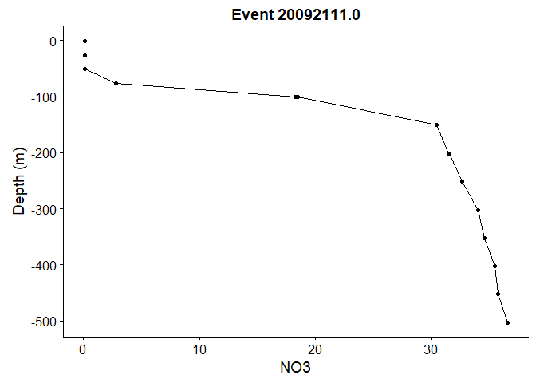

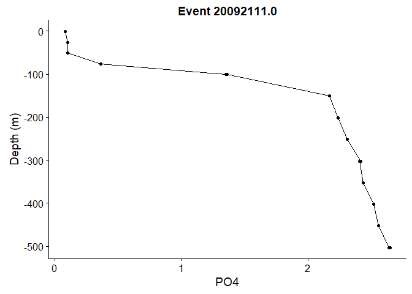

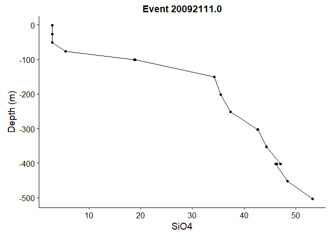

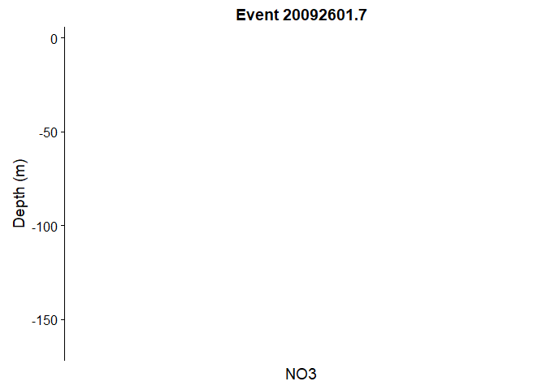

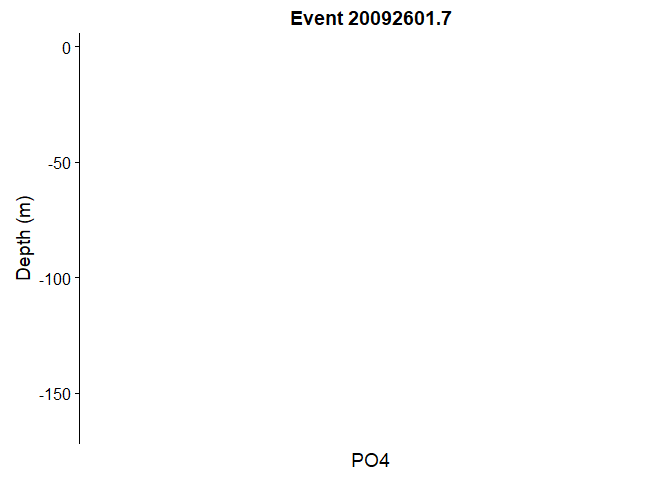

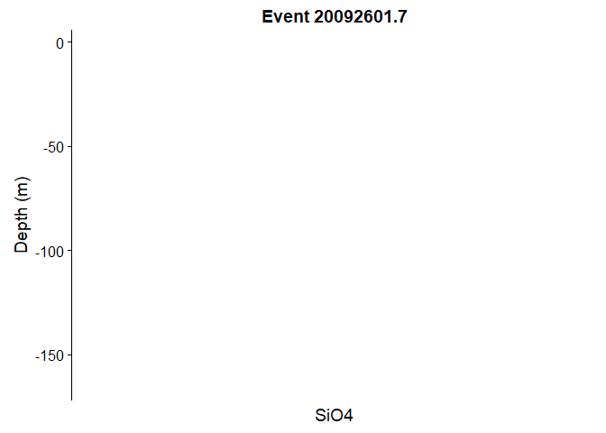

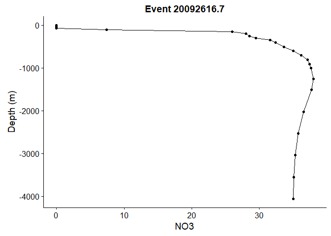

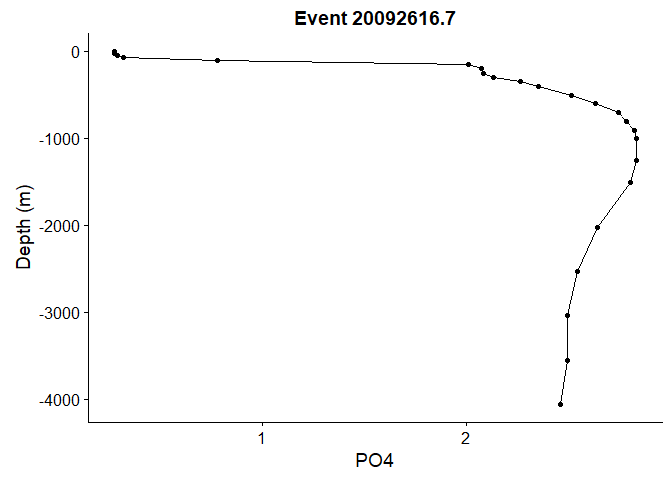

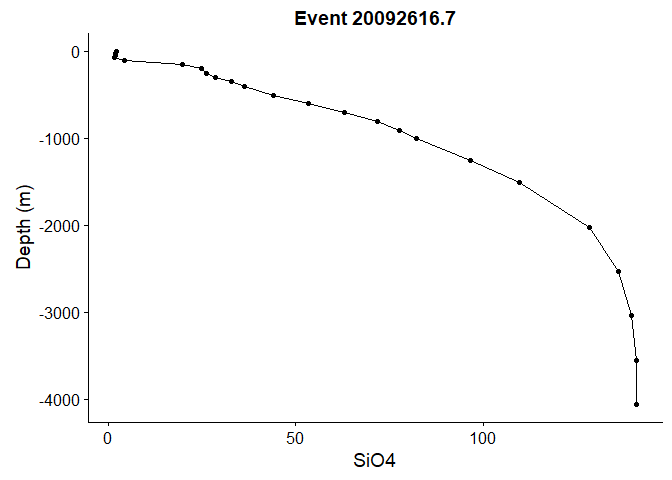

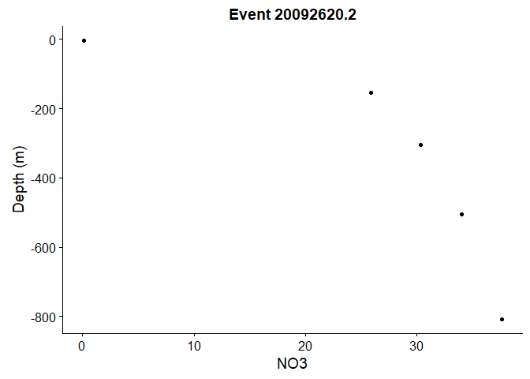

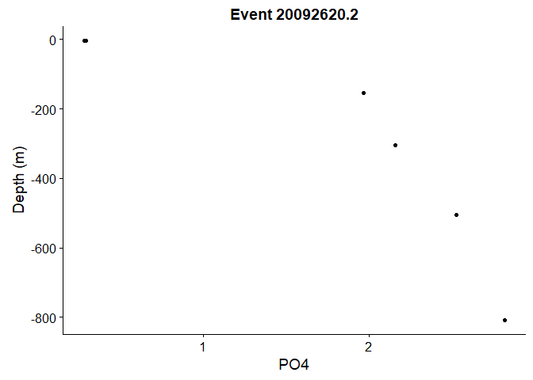

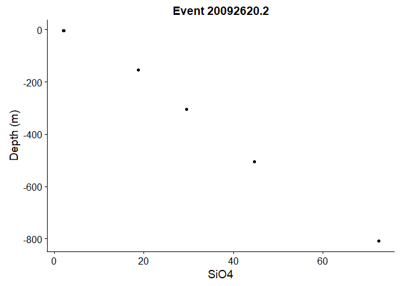

[96 more figures not shown]

```r
k <- 0
plot_list = list()
for  (i in 1:length(sub_URL)){
        page_title <- read_html(sub_URL[i])
        txt_data <- xml_text(page_title)
        data <- read.table(text=txt_data,skip=1,col.names=c('event','sta', "cast", "date", "time", "lat_begin",
        "lon_begin","bot", "press","temp", "sal_bot","O2_ml_L", "O2_umol_kg","O2_umol_L", "O2_4", "NO3",
        "PO4", "SiO4", "NO2", "NH4"), na.strings = "nd")
        data$depth <- -data$press
        for (j in 16:18) {
            k <- k+1
                variable <- colnames(data)[j]
                data[[variable]] <- as.numeric(data[[variable]])
                plot_list[[k]] <- ggplot(data=data, mapping=aes_string(x=variable, y="depth")) +
                        geom_point() +
                        geom_path() +
                        labs(x = colnames(data)[j], y = "Depth (m)", title = paste("Event", event[i],
                            sep = " "))
        }
}
print(plot_list)
```

```r
# Alternative way to print all plots (more complex way)
# plot_list <- c(plot_list, nrow=1)
# print(do.call(plot_grid, plot_list))
```

[This is the end of Homework 10.]